# **Project - Bank Churn Prediction**

### **Background and Context**

Businesses like banks that provide service have to worry about the problem of 'Churn' i.e. customers leaving and joining another service provider. It is important to understand which aspects of the service influence a customer's decision in this regard. Management can concentrate efforts on the improvement of service, keeping in mind these priorities.

### **Objective**

Given a Bank customer, build a neural network-based classifier that can determine whether they will leave or not in the next 6 months.

### **Data Description**

The case study is from an open-source dataset from Kaggle. The dataset contains 10,000 sample points with 14 distinct features such as CustomerId, CreditScore, Geography, Gender, Age, Tenure, Balance, etc.

### **Data Dictionary**

- RowNumber: Row number. CustomerId: Unique identification key for different customers.
- Surname: Surname of the customer
- Credit Score: A credit score is a measure of an individual's ability to pay back the borrowed amount. It is the numerical representation of their creditworthiness. A credit score is a 3-digit number that falls in the range of 300-900, 900 being the highest.
- Geography: The country to which the customer belongs.
- Gender: The gender of the customer.
- Age: Age of the customer.
- Tenure: The period of time a customer has been associated with the bank.
- Balance: The account balance (the amount of money deposited in the bank account) of the customer.
- NumOfProducts: How many accounts, bank account affiliated products the person has.
- HasCrCard: Does the customer have a credit card through the bank?
- IsActiveMember: Subjective, but for the concept
- EstimatedSalary: Estimated salary of the customer.
- Exited: Did they leave the bank after all?

```python
from google.colab import files
files.upload()
```

Upload widget is only available when the cell has been executed in the current browser session. Please rerun this cell to enable.

```
Saving bank.csv to bank (1).csv
```

[output not shown]

```python
#!pip install tensorflow
```

```python
import tensorflow as tf
print(tf.__version__)
```

```
2.5.0
```

### Reading Dataset and Feature Elimination

- Read the dataset properly - Print the overview of the data (statistical summary, shape, info, etc) - Eliminate the unique features from the dataset with proper reasoning

```python
import warnings
warnings.filterwarnings('ignore')

# Let's import the data and necessary libraries
import pandas as pd
import numpy as np
import seaborn as sns
import sklearn
from sklearn.model_selection import train_test_split
from sklearn import preprocessing
import matplotlib.pyplot as plt


bank_data = pd.read_csv('bank.csv')
bank_data.head(10)
```

|  | RowNumber | CustomerId | Surname | CreditScore | Geography | Gender | Age | Tenure | Balance | NumOfProducts | HasCrCard | IsActiveMember | EstimatedSalary | Exited |
| --- | --- | --- | --- | --- | --- | --- | --- | --- | --- | --- | --- | --- | --- | --- |
| 0 | 1 | 15634602 | Hargrave | 619 | France | Female | 42 | 2 | 0.00 | 1 | 1 | 1 | 101348.88 | 1 |
| 1 | 2 | 15647311 | Hill | 608 | Spain | Female | 41 | 1 | 83807.86 | 1 | 0 | 1 | 112542.58 | 0 |
| 2 | 3 | 15619304 | Onio | 502 | France | Female | 42 | 8 | 159660.80 | 3 | 1 | 0 | 113931.57 | 1 |
| 3 | 4 | 15701354 | Boni | 699 | France | Female | 39 | 1 | 0.00 | 2 | 0 | 0 | 93826.63 | 0 |
| 4 | 5 | 15737888 | Mitchell | 850 | Spain | Female | 43 | 2 | 125510.82 | 1 | 1 | 1 | 79084.10 | 0 |
| 5 | 6 | 15574012 | Chu | 645 | Spain | Male | 44 | 8 | 113755.78 | 2 | 1 | 0 | 149756.71 | 1 |
| 6 | 7 | 15592531 | Bartlett | 822 | France | Male | 50 | 7 | 0.00 | 2 | 1 | 1 | 10062.80 | 0 |
| 7 | 8 | 15656148 | Obinna | 376 | Germany | Female | 29 | 4 | 115046.74 | 4 | 1 | 0 | 119346.88 | 1 |
| 8 | 9 | 15792365 | He | 501 | France | Male | 44 | 4 | 142051.07 | 2 | 0 | 1 | 74940.50 | 0 |
| 9 | 10 | 15592389 | H? | 684 | France | Male | 27 | 2 | 134603.88 | 1 | 1 | 1 | 71725.73 | 0 |

```python
# Let's check null value in each column of the dataset
bank_data.isna().sum()
```

```
RowNumber          0
CustomerId         0
Surname            0
CreditScore        0
Geography          0
Gender             0
Age                0
Tenure             0
Balance            0
NumOfProducts      0
HasCrCard          0
IsActiveMember     0
EstimatedSalary    0
Exited             0
dtype: int64
```

- As we can see, there are no null values

```python
# Let's check missing value
bank_data.info()
```

```
<class 'pandas.core.frame.DataFrame'>
RangeIndex: 10000 entries, 0 to 9999
Data columns (total 14 columns):
 #   Column           Non-Null Count  Dtype
---  ------           --------------  -----
 0   RowNumber        10000 non-null  int64
 1   CustomerId       10000 non-null  int64
 2   Surname          10000 non-null  object
 3   CreditScore      10000 non-null  int64
 4   Geography        10000 non-null  object
 5   Gender           10000 non-null  object
 6   Age              10000 non-null  int64
 7   Tenure           10000 non-null  int64
 8   Balance          10000 non-null  float64
 9   NumOfProducts    10000 non-null  int64
 10  HasCrCard        10000 non-null  int64
 11  IsActiveMember   10000 non-null  int64
 12  EstimatedSalary  10000 non-null  float64
 13  Exited           10000 non-null  int64
dtypes: float64(2), int64(9), object(3)
memory usage: 1.1+ MB
```

- There are no any missing value and we have 10,000 rows or records and 14 columns
- RowNumber, CustomerID, and Surname will need to drop because they will not give any meaning to the model building, just unique identifier.
- Geography and Gender have Object as data type, we need to convert to category variable down the line.

```python
# Drop RowNumber and CustomerID
bank_data.drop(columns=['RowNumber','CustomerId','Surname'], inplace=True)
```

```python
# Check statistical summary
bank_data.describe()
```

|  | CreditScore | Age | Tenure | Balance | NumOfProducts | HasCrCard | IsActiveMember | EstimatedSalary | Exited |
| --- | --- | --- | --- | --- | --- | --- | --- | --- | --- |
| count | 10000.000000 | 10000.000000 | 10000.000000 | 10000.000000 | 10000.000000 | 10000.00000 | 10000.000000 | 10000.000000 | 10000.000000 |
| mean | 650.528800 | 38.921800 | 5.012800 | 76485.889288 | 1.530200 | 0.70550 | 0.515100 | 100090.239881 | 0.203700 |
| std | 96.653299 | 10.487806 | 2.892174 | 62397.405202 | 0.581654 | 0.45584 | 0.499797 | 57510.492818 | 0.402769 |
| min | 350.000000 | 18.000000 | 0.000000 | 0.000000 | 1.000000 | 0.00000 | 0.000000 | 11.580000 | 0.000000 |
| 25% | 584.000000 | 32.000000 | 3.000000 | 0.000000 | 1.000000 | 0.00000 | 0.000000 | 51002.110000 | 0.000000 |
| 50% | 652.000000 | 37.000000 | 5.000000 | 97198.540000 | 1.000000 | 1.00000 | 1.000000 | 100193.915000 | 0.000000 |
| 75% | 718.000000 | 44.000000 | 7.000000 | 127644.240000 | 2.000000 | 1.00000 | 1.000000 | 149388.247500 | 0.000000 |
| max | 850.000000 | 92.000000 | 10.000000 | 250898.090000 | 4.000000 | 1.00000 | 1.000000 | 199992.480000 | 1.000000 |

### Perform an Exploratory Data Analysis on the data

- Checked whether the dataset is balanced or not - Bivariate analysis - Use appropriate visualizations to identify the patterns and insights - Any other exploratory deep dive

### Illustrate the insights based on EDA

-Key meaningful observations from Bivariate analysis

```python
#Number of distinct categories or classes i.e., Exited and not
bank_data['Exited'].nunique()
```

```
2
```

- As expected, only 2 unique values

```python
# Checking the percentage of each class or balance of the dataset.
bank_data.Exited.value_counts()/bank_data.Exited.count()
```

```
0    0.7963
1    0.2037
Name: Exited, dtype: float64
```

- This shows that dataset is imbalance 80% not exited, and 20% exited.

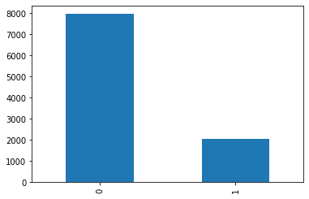

```python
#Visual representation of Exited
bank_data.Exited.value_counts().plot.bar()
```

- Visualization gives better clear picture of imbalance dataset.

#### Univariate

```python
# While doing uni-variate analysis of numerical variables, we want to study their central tendency and dispersion.
# Let's write a function that will help us create boxplot and histogram for any numerical input variables.
def histogram_boxplot(feature, figsize=(15,10), bins=None):
    """Boxplot and histogram combined
    feature: 1-d feature array
    figsize: size of fig (default (9,8))
    bins: number of bins (defualt None / auto)
    """
    f2, (ax_box2, ax_hist2) = plt.subplots(
        nrows=2,  # Number of rows of the subplot grid= 2
        sharex=True,  # x-axis will be shared among all subplots
        gridspec_kw={"height_ratios": (0.25, 0.75)},
        figsize=figsize,
    )  # creating the 2 subplots
    sns.boxplot(
        feature, ax=ax_box2, showmeans=True, color="violet"
    )  # boxplot will be created and a star will indicate the mean value of the column
    sns.distplot(
        feature, kde=F, ax=ax_hist2, bins=bins, palette="winter"
    ) if bins else sns.distplot(
        feature, kde=False, ax=ax_hist2
    )  # For histogram
    ax_hist2.axvline(
        np.mean(feature), color="green", linestyle="--"
    )  # Add mean to the histogram
    ax_hist2.axvline(
        np.median(feature), color="black", linestyle="-"
    )  # Add median to the histogram
```

```python
bank_data.columns
```

```
Index(['CreditScore', 'Geography', 'Gender', 'Age', 'Tenure', 'Balance',
       'NumOfProducts', 'HasCrCard', 'IsActiveMember', 'EstimatedSalary',
       'Exited'],
      dtype='object')
```

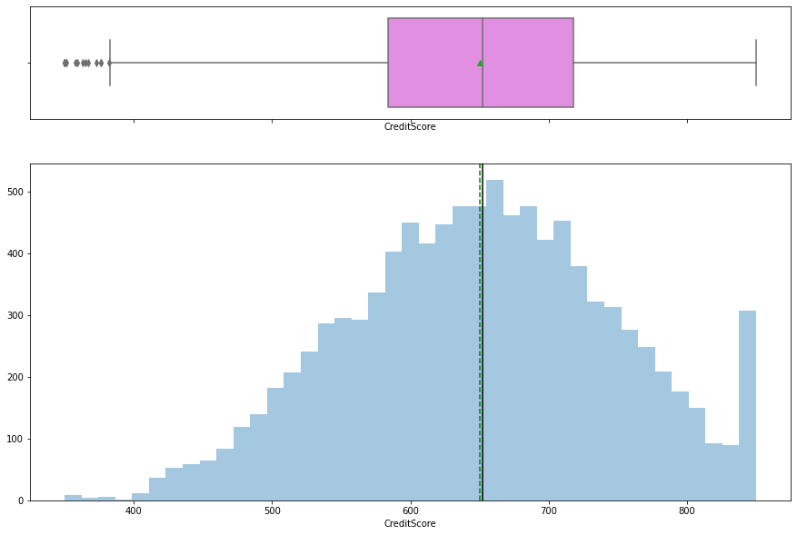

```python
# Observation on CreditScore
histogram_boxplot(bank_data['CreditScore'])
```

- There are some outlier on the left, but this is expected in the real world. Some people have very low credit score.
- Mean and Median are almost symmetric around 650

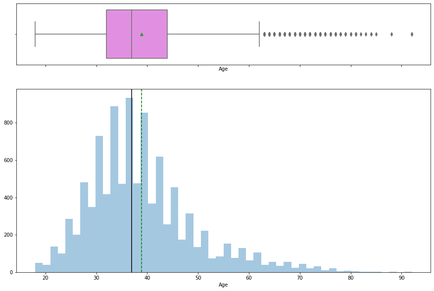

```python
# Observation on Age
histogram_boxplot(bank_data['Age'])
```

- There are outlier on the right. We might need to drop them. let's check more on that.
- Most customers are between 30-40 years old.

```python
bank_data[bank_data['Age'] > 85]
```

|  | CreditScore | Geography | Gender | Age | Tenure | Balance | NumOfProducts | HasCrCard | IsActiveMember | EstimatedSalary | Exited |
| --- | --- | --- | --- | --- | --- | --- | --- | --- | --- | --- | --- |
| 2458 | 513 | Spain | Male | 88 | 10 | 0.00 | 2 | 1 | 1 | 52952.24 | 0 |
| 6443 | 753 | France | Male | 92 | 3 | 121513.31 | 1 | 0 | 1 | 195563.99 | 0 |
| 6759 | 705 | France | Male | 92 | 1 | 126076.24 | 2 | 1 | 1 | 34436.83 | 0 |

```python
#clip customer at higher than 85 years old. only 3 records in the dataset.
bank_data['Age'].clip(upper=85, inplace=True)
```

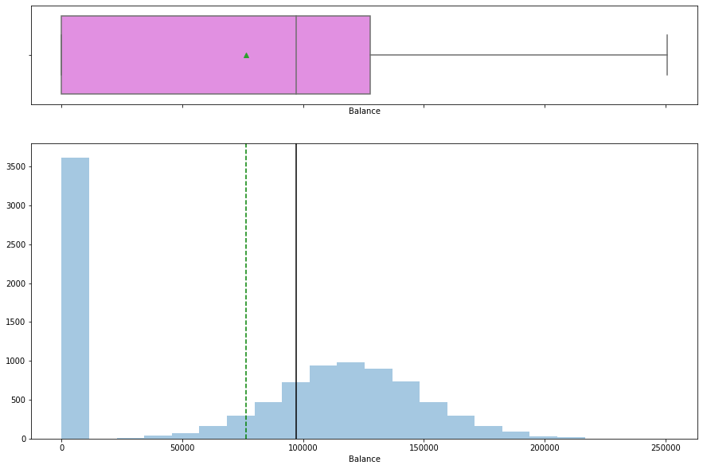

```python
histogram_boxplot(bank_data['Balance'])
```

- A lot of customers have 0 balance in their bank account. This is something that the Bank might need to revisit why this kind of thing happened.

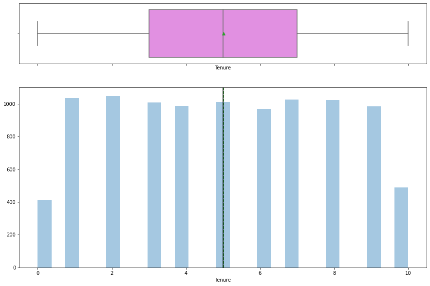

```python
histogram_boxplot(bank_data['Tenure'])
```

- Mean and Median are symmetric is 5 years with the Bank.

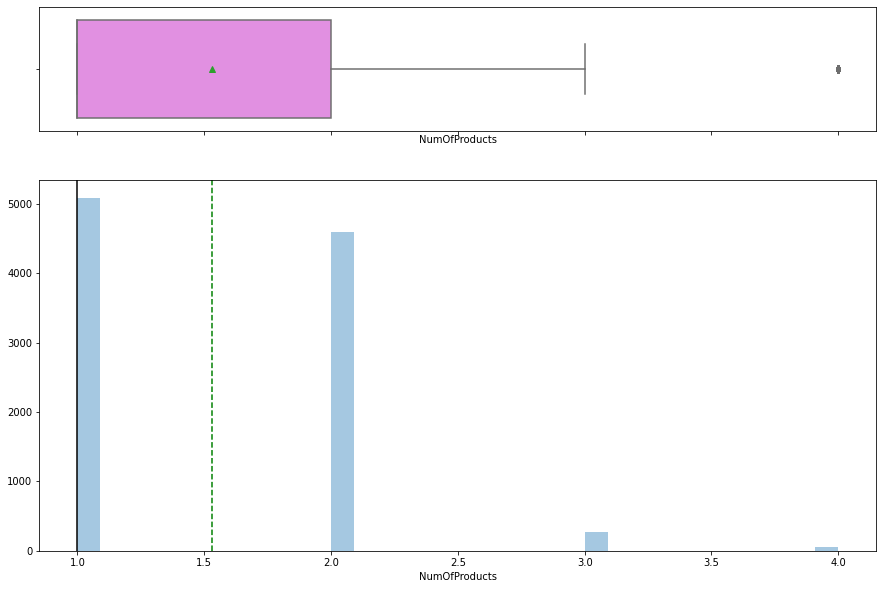

```python
histogram_boxplot(bank_data['NumOfProducts'])
```

```python
bank_data[bank_data['NumOfProducts'] > 3]
```

|  | CreditScore | Geography | Gender | Age | Tenure | Balance | NumOfProducts | HasCrCard | IsActiveMember | EstimatedSalary | Exited |
| --- | --- | --- | --- | --- | --- | --- | --- | --- | --- | --- | --- |
| 7 | 376 | Germany | Female | 29 | 4 | 115046.74 | 4 | 1 | 0 | 119346.88 | 1 |
| 70 | 738 | Germany | Male | 58 | 2 | 133745.44 | 4 | 1 | 0 | 28373.86 | 1 |
| 1254 | 628 | France | Female | 46 | 1 | 46870.43 | 4 | 1 | 0 | 31272.14 | 1 |
| 1469 | 819 | Germany | Female | 49 | 1 | 120656.86 | 4 | 0 | 0 | 166164.30 | 1 |
| 1488 | 596 | Spain | Male | 30 | 6 | 121345.88 | 4 | 1 | 0 | 41921.75 | 1 |
| 1701 | 792 | France | Male | 50 | 9 | 0.00 | 4 | 1 | 1 | 194700.81 | 1 |
| 1876 | 640 | Germany | Male | 39 | 9 | 131607.28 | 4 | 0 | 1 | 6981.43 | 1 |
| 2124 | 704 | France | Male | 32 | 7 | 127785.17 | 4 | 0 | 0 | 184464.70 | 1 |
| 2196 | 773 | Germany | Male | 47 | 2 | 118079.47 | 4 | 1 | 1 | 143007.49 | 1 |
| 2285 | 630 | Germany | Male | 50 | 3 | 129370.91 | 4 | 1 | 1 | 47775.34 | 1 |
| 2462 | 672 | France | Female | 53 | 9 | 169406.33 | 4 | 1 | 1 | 147311.47 | 1 |
| 2499 | 614 | France | Female | 37 | 8 | 75150.34 | 4 | 0 | 1 | 131766.67 | 1 |
| 2509 | 655 | France | Female | 50 | 10 | 0.00 | 4 | 1 | 0 | 179267.94 | 1 |
| 2541 | 611 | France | Female | 61 | 3 | 131583.59 | 4 | 0 | 1 | 66238.23 | 1 |
| 2614 | 546 | Germany | Female | 58 | 3 | 106458.31 | 4 | 1 | 0 | 128881.87 | 1 |
| 2617 | 692 | Germany | Male | 45 | 6 | 152296.83 | 4 | 0 | 1 | 108040.86 | 1 |
| 2872 | 439 | Spain | Male | 52 | 3 | 96196.24 | 4 | 1 | 0 | 198874.52 | 1 |
| 3152 | 644 | France | Female | 40 | 9 | 137285.26 | 4 | 1 | 0 | 77063.63 | 1 |
| 3365 | 671 | Spain | Female | 34 | 5 | 130929.02 | 4 | 1 | 1 | 28238.25 | 1 |
| 3841 | 653 | France | Female | 60 | 2 | 120731.39 | 4 | 1 | 1 | 138160.11 | 1 |
| 4013 | 720 | Germany | Female | 57 | 1 | 162082.31 | 4 | 0 | 0 | 27145.73 | 1 |
| 4014 | 641 | Germany | Female | 51 | 2 | 117306.69 | 4 | 1 | 1 | 26912.72 | 1 |
| 4166 | 850 | Spain | Female | 45 | 5 | 174088.30 | 4 | 1 | 0 | 5669.31 | 1 |
| 4260 | 587 | France | Male | 40 | 2 | 0.00 | 4 | 0 | 1 | 106174.70 | 1 |
| 4403 | 602 | Germany | Female | 43 | 2 | 113641.49 | 4 | 1 | 0 | 115116.35 | 1 |
| 4511 | 634 | France | Female | 45 | 2 | 0.00 | 4 | 1 | 0 | 101039.53 | 1 |
| 4516 | 497 | Germany | Female | 32 | 8 | 111537.23 | 4 | 1 | 1 | 9497.99 | 1 |
| 4606 | 797 | France | Female | 55 | 10 | 0.00 | 4 | 1 | 1 | 49418.87 | 1 |
| 4654 | 578 | Germany | Female | 31 | 5 | 102088.68 | 4 | 0 | 0 | 187866.21 | 1 |
| 4748 | 537 | Germany | Female | 37 | 7 | 158411.95 | 4 | 1 | 1 | 117690.58 | 1 |
| 4822 | 745 | France | Female | 32 | 2 | 0.00 | 4 | 0 | 1 | 179705.13 | 1 |
| 5010 | 575 | Germany | Male | 49 | 7 | 121205.15 | 4 | 1 | 1 | 168080.53 | 1 |
| 5137 | 698 | France | Female | 51 | 6 | 144237.91 | 4 | 1 | 0 | 157143.61 | 1 |
| 5235 | 645 | France | Female | 68 | 9 | 0.00 | 4 | 1 | 1 | 176353.87 | 1 |
| 5386 | 642 | France | Male | 48 | 9 | 118317.27 | 4 | 0 | 0 | 78702.98 | 1 |
| 5700 | 447 | France | Male | 41 | 3 | 0.00 | 4 | 1 | 1 | 197490.39 | 1 |
| 5904 | 692 | Germany | Male | 45 | 6 | 142084.04 | 4 | 1 | 0 | 188305.85 | 1 |
| 6150 | 632 | Germany | Male | 41 | 8 | 127205.32 | 4 | 1 | 0 | 93874.87 | 1 |
| 6172 | 568 | Germany | Male | 43 | 5 | 87612.64 | 4 | 1 | 1 | 107155.40 | 1 |
| 6279 | 757 | Spain | Female | 55 | 9 | 117294.12 | 4 | 1 | 0 | 94187.47 | 1 |
| 6750 | 618 | France | Female | 42 | 2 | 0.00 | 4 | 0 | 0 | 111097.39 | 1 |
| 6875 | 610 | France | Female | 57 | 7 | 72092.95 | 4 | 0 | 1 | 113228.82 | 1 |
| 7257 | 747 | France | Female | 47 | 5 | 139914.60 | 4 | 0 | 1 | 129964.56 | 1 |
| 7457 | 665 | Germany | Female | 43 | 2 | 116322.27 | 4 | 1 | 0 | 35640.12 | 1 |
| 7567 | 629 | France | Male | 44 | 5 | 0.00 | 4 | 0 | 0 | 117572.59 | 1 |
| 7698 | 592 | France | Male | 60 | 9 | 0.00 | 4 | 1 | 1 | 13614.01 | 1 |
| 7724 | 842 | France | Male | 44 | 3 | 141252.18 | 4 | 0 | 1 | 128521.16 | 1 |
| 7729 | 850 | France | Female | 35 | 2 | 128548.49 | 4 | 1 | 0 | 75478.95 | 1 |
| 8041 | 698 | Spain | Female | 50 | 1 | 0.00 | 4 | 1 | 0 | 88566.90 | 1 |
| 8590 | 771 | France | Female | 41 | 10 | 108309.00 | 4 | 1 | 1 | 137510.41 | 1 |
| 8683 | 697 | France | Female | 49 | 7 | 195238.29 | 4 | 0 | 1 | 131083.56 | 1 |
| 8850 | 500 | Spain | Female | 50 | 5 | 0.00 | 4 | 1 | 1 | 83866.35 | 1 |
| 8923 | 625 | Germany | Female | 55 | 8 | 118772.71 | 4 | 0 | 0 | 135853.62 | 1 |
| 9215 | 584 | Germany | Female | 37 | 10 | 134171.80 | 4 | 1 | 1 | 70927.11 | 1 |
| 9255 | 847 | Germany | Female | 41 | 3 | 101543.51 | 4 | 1 | 0 | 16025.17 | 1 |
| 9323 | 644 | France | Male | 50 | 9 | 76817.00 | 4 | 1 | 0 | 196371.13 | 1 |
| 9370 | 561 | France | Male | 43 | 4 | 0.00 | 4 | 0 | 0 | 18522.91 | 1 |
| 9411 | 689 | Germany | Female | 40 | 4 | 78119.59 | 4 | 1 | 0 | 119259.34 | 1 |
| 9540 | 727 | Germany | Male | 46 | 3 | 115248.11 | 4 | 1 | 0 | 130752.01 | 1 |
| 9565 | 582 | France | Female | 38 | 9 | 135979.01 | 4 | 1 | 1 | 76582.95 | 1 |

- There are a lot records which have 4 number of Product. Let's not do anything with that.

```python
# Let's create function for cateogry variable.
def perc_on_bar(feature):
    """
    plot
    feature: categorical feature
    the function won't work if a column is passed in hue parameter
    """
    # Creating a countplot for the feature
    sns.set(rc={"figure.figsize": (10, 5)})
    ax = sns.countplot(x=feature, data=bank_data)

    total = len(feature)  # length of the column
    for p in ax.patches:
        percentage = "{:.1f}%".format(
            100 * p.get_height() / total
        )  # percentage of each class of the category
        x = p.get_x() + p.get_width() / 2 - 0.1  # width of the plot
        y = p.get_y() + p.get_height()  # hieght of the plot
        ax.annotate(percentage, (x, y), size=14)  # annotate the percantage

    plt.show()  # show the plot
```

```python
# Convert Gender and Geography to categorical.
bank_data['Gender'] = bank_data['Gender'].astype('category')
bank_data['Geography'] = bank_data['Geography'].astype('category')
```

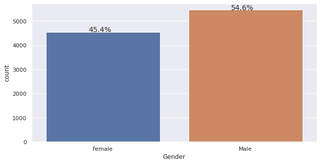

```python
# Observation on Gender
perc_on_bar( bank_data['Gender'])
```

- Customer 54.6% are Male and 45.4% are Female.

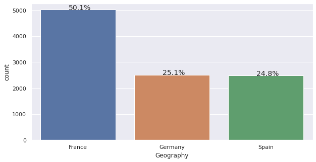

```python
# Observation on Geography
perc_on_bar(bank_data['Geography'])
```

- 50.1% customers are live in France, Germany for 25.1%, and 24.8% live in Spain.

#### Bivariate Analysis

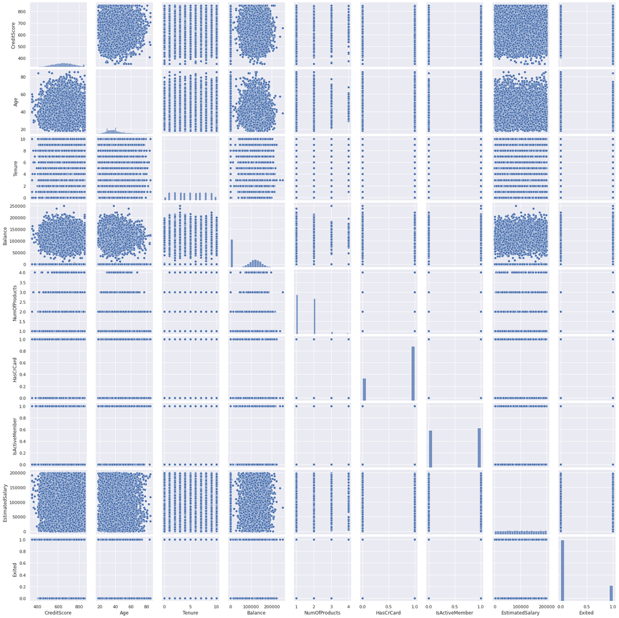

```python
sns.pairplot(bank_data)
```

- There are not much correction between those features.

```python
bank_data.columns
```

```
Index(['CreditScore', 'Geography', 'Gender', 'Age', 'Tenure', 'Balance',
       'NumOfProducts', 'HasCrCard', 'IsActiveMember', 'EstimatedSalary',
       'Exited'],
      dtype='object')
```

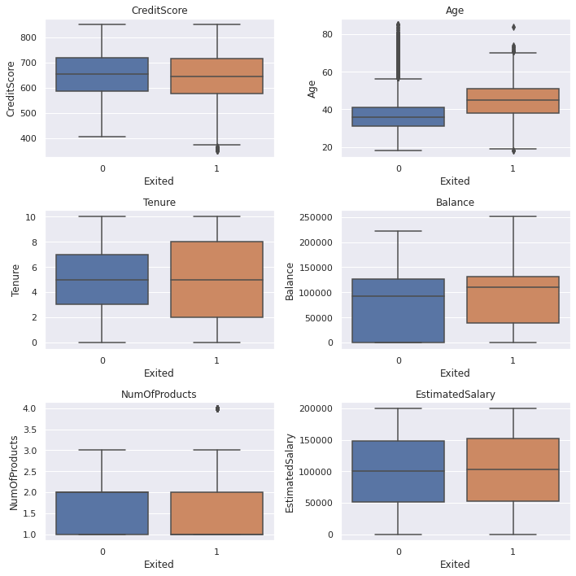

```python
cols = bank_data[["CreditScore","Age", "Tenure","Balance", "NumOfProducts", "EstimatedSalary"]].columns.tolist()
plt.figure(figsize=(10, 10))

for i, variable in enumerate(cols):
    plt.subplot(3, 2, i + 1)
    sns.boxplot(bank_data["Exited"], bank_data[variable])
    plt.tight_layout()
    plt.title(variable)
plt.show()
```

- not much to interpret here. Only Age feature Exited 1 a little higher than 0. It means that older customer more likely exited than younger customers.

```python
### Function to plot stacked bar charts for categorical columns
def stacked_plot(x):
    sns.set(palette="nipy_spectral")
    tab1 = pd.crosstab(x, bank_data["Exited"], margins=True)
    print(tab1)
    print("-" * 120)
    tab = pd.crosstab(x, bank_data["Exited"], normalize="index")
    tab.plot(kind="bar", stacked=True, figsize=(10, 5))
    plt.legend(loc="lower left", frameon=False)
    plt.legend(loc="upper left", bbox_to_anchor=(1, 1))
    plt.show()
```

```
Exited     0     1    All
Gender
Female  3404  1139   4543
Male    4559   898   5457
All     7963  2037  10000
------------------------------------------------------------------------------------------------------------------------
```

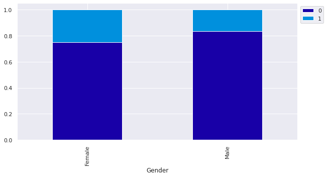

```python
stacked_plot(bank_data["Gender"])
```

- Female customer more likely exited more than Male customer.

```
Exited        0     1    All
Geography
France     4204   810   5014
Germany    1695   814   2509
Spain      2064   413   2477
All        7963  2037  10000
------------------------------------------------------------------------------------------------------------------------
```

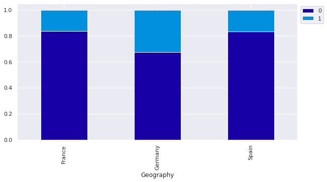

```python
stacked_plot(bank_data["Geography"])
```

- Customers in Germany more likely exited more than customer in France and Spain.

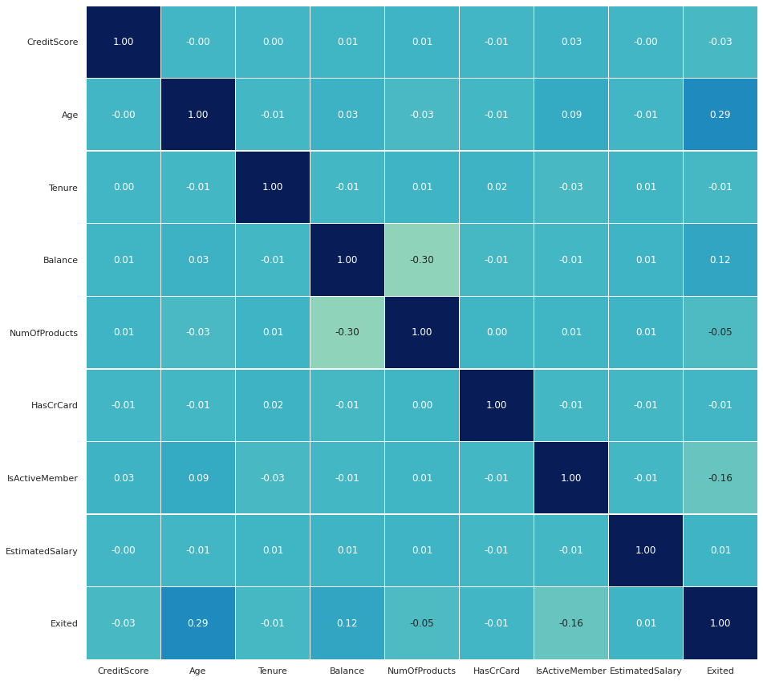

```python
sns.set(rc={"figure.figsize": (15, 15)})
sns.heatmap(
    bank_data.corr(),
    annot=True,
    linewidths=0.5,
    center=0,
    cbar=False,
    cmap="YlGnBu",
    fmt="0.2f",
)
plt.show()
```

- Like we saw in the pair plot, there are not much correction here.

### Data Pre-processing

- Split the target variable and predictors
- Split the data into train and test - Rescale the data

```python
X_data = bank_data.iloc[:,0:10]
y_data = bank_data.iloc[:, -1]
```

```python
#printing the shape of the data
print(X_data.shape)
print(y_data.shape)
```

```
(10000, 10)
(10000,)
```

```python
X_data.head()
```

|  | CreditScore | Geography | Gender | Age | Tenure | Balance | NumOfProducts | HasCrCard | IsActiveMember | EstimatedSalary |
| --- | --- | --- | --- | --- | --- | --- | --- | --- | --- | --- |
| 0 | 619 | France | Female | 42 | 2 | 0.00 | 1 | 1 | 1 | 101348.88 |
| 1 | 608 | Spain | Female | 41 | 1 | 83807.86 | 1 | 0 | 1 | 112542.58 |
| 2 | 502 | France | Female | 42 | 8 | 159660.80 | 3 | 1 | 0 | 113931.57 |
| 3 | 699 | France | Female | 39 | 1 | 0.00 | 2 | 0 | 0 | 93826.63 |
| 4 | 850 | Spain | Female | 43 | 2 | 125510.82 | 1 | 1 | 1 | 79084.10 |

```python
from sklearn.preprocessing import StandardScaler
numerical_col = ["CreditScore","Age","Tenure","Balance","NumOfProducts","EstimatedSalary"]
X_data1 = X_data.copy()
for col in numerical_col:
  X_data1[col] = StandardScaler().fit_transform(X_data1[col].values.reshape(-1,1))
X_data1
```

|  | CreditScore | Geography | Gender | Age | Tenure | Balance | NumOfProducts | HasCrCard | IsActiveMember | EstimatedSalary |
| --- | --- | --- | --- | --- | --- | --- | --- | --- | --- | --- |
| 0 | -0.326221 | France | Female | 0.293903 | -1.041760 | -1.225848 | -0.911583 | 1 | 1 | 0.021886 |
| 1 | -0.440036 | Spain | Female | 0.198477 | -1.387538 | 0.117350 | -0.911583 | 0 | 1 | 0.216534 |
| 2 | -1.536794 | France | Female | 0.293903 | 1.032908 | 1.333053 | 2.527057 | 1 | 0 | 0.240687 |
| 3 | 0.501521 | France | Female | 0.007625 | -1.387538 | -1.225848 | 0.807737 | 0 | 0 | -0.108918 |
| 4 | 2.063884 | Spain | Female | 0.389329 | -1.041760 | 0.785728 | -0.911583 | 1 | 1 | -0.365276 |
| ... | ... | ... | ... | ... | ... | ... | ... | ... | ... | ... |
| 9995 | 1.246488 | France | Male | 0.007625 | -0.004426 | -1.225848 | 0.807737 | 1 | 0 | -0.066419 |
| 9996 | -1.391939 | France | Male | -0.374080 | 1.724464 | -0.306379 | -0.911583 | 1 | 1 | 0.027988 |
| 9997 | 0.604988 | France | Female | -0.278654 | 0.687130 | -1.225848 | -0.911583 | 0 | 1 | -1.008643 |
| 9998 | 1.256835 | Germany | Male | 0.293903 | -0.695982 | -0.022608 | 0.807737 | 1 | 0 | -0.125231 |
| 9999 | 1.463771 | France | Female | -1.042064 | -0.350204 | 0.859965 | -0.911583 | 1 | 0 | -1.076370 |

10000 rows × 10 columns

```python
# Encoding Categorical variables
X_data1 = pd.get_dummies(X_data1, drop_first=True)
```

```python
X_data1
```

|  | CreditScore | Age | Tenure | Balance | NumOfProducts | HasCrCard | IsActiveMember | EstimatedSalary | Geography_Germany | Geography_Spain | Gender_Male |
| --- | --- | --- | --- | --- | --- | --- | --- | --- | --- | --- | --- |
| 0 | -0.326221 | 0.293903 | -1.041760 | -1.225848 | -0.911583 | 1 | 1 | 0.021886 | 0 | 0 | 0 |
| 1 | -0.440036 | 0.198477 | -1.387538 | 0.117350 | -0.911583 | 0 | 1 | 0.216534 | 0 | 1 | 0 |
| 2 | -1.536794 | 0.293903 | 1.032908 | 1.333053 | 2.527057 | 1 | 0 | 0.240687 | 0 | 0 | 0 |
| 3 | 0.501521 | 0.007625 | -1.387538 | -1.225848 | 0.807737 | 0 | 0 | -0.108918 | 0 | 0 | 0 |
| 4 | 2.063884 | 0.389329 | -1.041760 | 0.785728 | -0.911583 | 1 | 1 | -0.365276 | 0 | 1 | 0 |
| ... | ... | ... | ... | ... | ... | ... | ... | ... | ... | ... | ... |
| 9995 | 1.246488 | 0.007625 | -0.004426 | -1.225848 | 0.807737 | 1 | 0 | -0.066419 | 0 | 0 | 1 |
| 9996 | -1.391939 | -0.374080 | 1.724464 | -0.306379 | -0.911583 | 1 | 1 | 0.027988 | 0 | 0 | 1 |
| 9997 | 0.604988 | -0.278654 | 0.687130 | -1.225848 | -0.911583 | 0 | 1 | -1.008643 | 0 | 0 | 0 |
| 9998 | 1.256835 | 0.293903 | -0.695982 | -0.022608 | 0.807737 | 1 | 0 | -0.125231 | 1 | 0 | 1 |
| 9999 | 1.463771 | -1.042064 | -0.350204 | 0.859965 | -0.911583 | 1 | 0 | -1.076370 | 0 | 0 | 0 |

10000 rows × 11 columns

```python
# Splitting the Data into train and test set
X_train, X_test, y_train, y_test = train_test_split(X_data1, y_data, test_size=0.2, random_state=7)
```

```python
print(X_train.shape)
print(X_test.shape)
print(y_train.shape)
print(y_test.shape)
```

```
(8000, 11)
(2000, 11)
(8000,)
(2000,)
```

### Model building : Neural Network

- We wiill use a smiple NN made of 5 fully-connected layers with ReLu activiation. The NN takes a vector of length 11 as input. This represents the information related to each customer, ie each line with 11 columns from the dataset.
- For each customer, the final layer will output a probability (sigmoid activation function) and classify either as not exited (0) and exited (1).

### Creating a model

Keras model object can be created with Sequential class At the outset, the model is empty per se. it is completed by adding additional layers and compilation.

```python
import keras
import tensorflow as tf
from keras.models import  Sequential
from keras.layers import  Dense,Dropout
from keras.optimizers import Adam
```

```python
#initialize the model
model = Sequential()
```

### Adding Layers [layers and activations]

- Keras layers can be added to the model
- Adding layers are like stacking lego blocks one by one
- It should be noted that as this is a classification problem, sigmoid layer (softmax for multi-class problems) should be added.

```python
# This adds the input layer (by specifying input dimension) and the firt hidden layer (units)
model.add(Dense(units=16, input_dim= 11, activation='relu')) # input of 11 columns as shown above
# Adding hidden layers
model.add(Dense(units=24, activation='relu'))
model.add(Dense(units=24, activation='relu'))
model.add(Dense(units=24, activation='relu'))
# Addding the output layer
# Notice that we do not need to specify input dim.
# We have an output of 1 node, which is the desired dimensions of our output (Exited or not)
# We use the sigmoid becuase we want probability outcomes (binary classification)
model.add(Dense(1,activation='sigmoid'))
```

### Model compile [optimizers and loss functions]

- Keras model should be "compiled" prior to training
- Types of loss (function) and optimizer should be designated
- We use Recall as our metrics because Bank should focus on True Positive prediction. True positive is expensive for the Bank business since it will lose customers.

```python
# Create optimizer with default learning rate
# Compile the model
model.compile(optimizer='adam', loss='binary_crossentropy',metrics=['Recall'])
```

### Let's print the summary of the model

```python
model.summary()
```

```
Model: "sequential_4"
_________________________________________________________________
Layer (type)                 Output Shape              Param #
=================================================================
dense_22 (Dense)             (None, 16)                192
_________________________________________________________________
dense_23 (Dense)             (None, 24)                408
_________________________________________________________________
dense_24 (Dense)             (None, 24)                600
_________________________________________________________________
dense_25 (Dense)             (None, 24)                600
_________________________________________________________________
dense_26 (Dense)             (None, 1)                 25
=================================================================
Total params: 1,825
Trainable params: 1,825
Non-trainable params: 0
_________________________________________________________________
```

### Training [Forward pass and Backpropagation]

Training the model

```python
# fitting the model
history = model.fit(X_train, y_train, batch_size=15, epochs=10, validation_split=0.2)
```

### Plotting the train and test loss

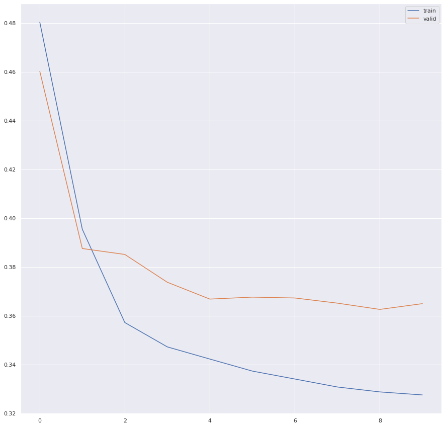

```python
# Capturing learning history per epoch
hist = pd.DataFrame(history.history)
hist['epoch'] = history.epoch

# Plotting recall at different epochs
plt.plot(hist['loss'])
plt.plot(hist['val_loss'])
plt.legend(('train','valid'), loc =0)
```

- Observation: Model is overfitting. There are a lot of different between training and testing.

### Model Performance Improvement

- Comment on which metric is right for model performance evaluation and why?
- Find the optimal threshold using ROC-AUC or Precision-Recall curves
- Comment on model performance
- Can model performance be improved? check and comment
- Build another model to implement these improvements
- Include all the model which were trained to reach at the final one

### Model Performance Evaluation

- Evaluate the model on different performance metrics and comment on the performance and scope of improvement

##### - We use Recall matric for this model performance evaluation because True Positive is expensive for the Bank. Losing customer is a big deal for the Bank.

#### Find the optimal threshold using ROC-AUC curves

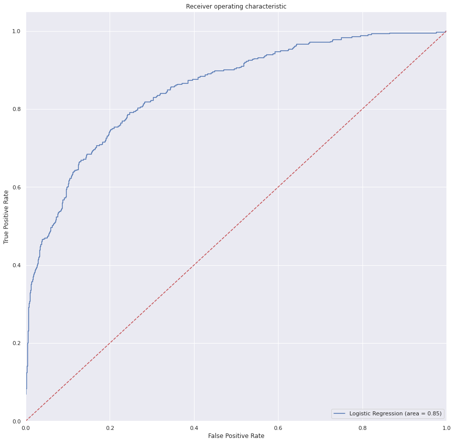

```python
from sklearn.metrics import roc_auc_score
from sklearn.metrics import roc_curve

logit_roc_auc = roc_auc_score(y_test, model.predict_proba(X_test))
fpr, tpr, thresholds = roc_curve(y_test, model.predict_proba(X_test))
plt.figure()
plt.plot(fpr, tpr, label='Logistic Regression (area = %0.2f)' % logit_roc_auc)
plt.plot([0, 1], [0, 1],'r--')
plt.xlim([0.0, 1.0])
plt.ylim([0.0, 1.05])
plt.xlabel('False Positive Rate')
plt.ylabel('True Positive Rate')
plt.title('Receiver operating characteristic')
plt.legend(loc="lower right")
plt.savefig('Log_ROC')
plt.show()
```

```python
def Find_Optimal_Cutoff(target, predicted):
    """ Find the optimal probability cutoff point for a classification model related to event rate
    Parameters
    ----------
    target : Matrix with dependent or target data, where rows are observations

    predicted : Matrix with predicted data, where rows are observations

    Returns
    -------
    list type, with optimal cutoff value

    """
    fpr, tpr, threshold = roc_curve(target, predicted)
    i = np.arange(len(tpr))
    roc = pd.DataFrame({'tf' : pd.Series(tpr-(1-fpr), index=i), 'threshold' : pd.Series(threshold, index=i)})
    roc_t = roc.iloc[(roc.tf-0).abs().argsort()[:1]]

    return list(roc_t['threshold'])


# Add prediction probability to dataframe
pred_proba = model.predict(X_test)

# Find optimal probability threshold
threshold = Find_Optimal_Cutoff(y_test, pred_proba)
print(threshold)
```

```
[0.15736863017082214]
```

- The optimal threshold is 0.15 of this model.

### Evaluation

- Keras model can be evaluated with evaluate() function
- Evaluation results are contained in a list

```python
score = model.evaluate(X_test, y_test)
```

[output not shown]

##### Let's Print confusion matrix

```python
def make_confusion_matrix(cf,
                          group_names=None,
                          categories='auto',
                          count=True,
                          percent=True,
                          cbar=True,
                          xyticks=True,
                          xyplotlabels=True,
                          sum_stats=True,
                          figsize=None,
                          cmap='Blues',
                          title=None):
    '''
    This function will make a pretty plot of an sklearn Confusion Matrix cm using a Seaborn heatmap visualization.
    Arguments
    '''


    # CODE TO GENERATE TEXT INSIDE EACH SQUARE
    blanks = ['' for i in range(cf.size)]

    if group_names and len(group_names)==cf.size:
        group_labels = ["{}\n".format(value) for value in group_names]
    else:
        group_labels = blanks

    if count:
        group_counts = ["{0:0.0f}\n".format(value) for value in cf.flatten()]
    else:
        group_counts = blanks

    if percent:
        group_percentages = ["{0:.2%}".format(value) for value in cf.flatten()/np.sum(cf)]
    else:
        group_percentages = blanks

    box_labels = [f"{v1}{v2}{v3}".strip() for v1, v2, v3 in zip(group_labels,group_counts,group_percentages)]
    box_labels = np.asarray(box_labels).reshape(cf.shape[0],cf.shape[1])


    # CODE TO GENERATE SUMMARY STATISTICS & TEXT FOR SUMMARY STATS
    if sum_stats:
        #Accuracy is sum of diagonal divided by total observations
        accuracy  = np.trace(cf) / float(np.sum(cf))

        #if it is a binary confusion matrix, show some more stats
        if len(cf)==2:
            #Metrics for Binary Confusion Matrices
            precision = cf[1,1] / sum(cf[:,1])
            recall    = cf[1,1] / sum(cf[1,:])
            f1_score  = 2*precision*recall / (precision + recall)
            stats_text = "\n\nAccuracy={:0.3f}\nPrecision={:0.3f}\nRecall={:0.3f}\nF1 Score={:0.3f}".format(
                accuracy,precision,recall,f1_score)
        else:
            stats_text = "\n\nAccuracy={:0.3f}".format(accuracy)
    else:
        stats_text = ""


    # SET FIGURE PARAMETERS ACCORDING TO OTHER ARGUMENTS
    if figsize==None:
        #Get default figure size if not set
        figsize = plt.rcParams.get('figure.figsize')

    if xyticks==False:
        #Do not show categories if xyticks is False
        categories=False


    # MAKE THE HEATMAP VISUALIZATION
    plt.figure(figsize=figsize)
    sns.heatmap(cf,annot=box_labels,fmt="",cmap=cmap,cbar=cbar,xticklabels=categories,yticklabels=categories)

    if xyplotlabels:
        plt.ylabel('True label')
        plt.xlabel('Predicted label' + stats_text)
    else:
        plt.xlabel(stats_text)

    if title:
        plt.title(title)
```

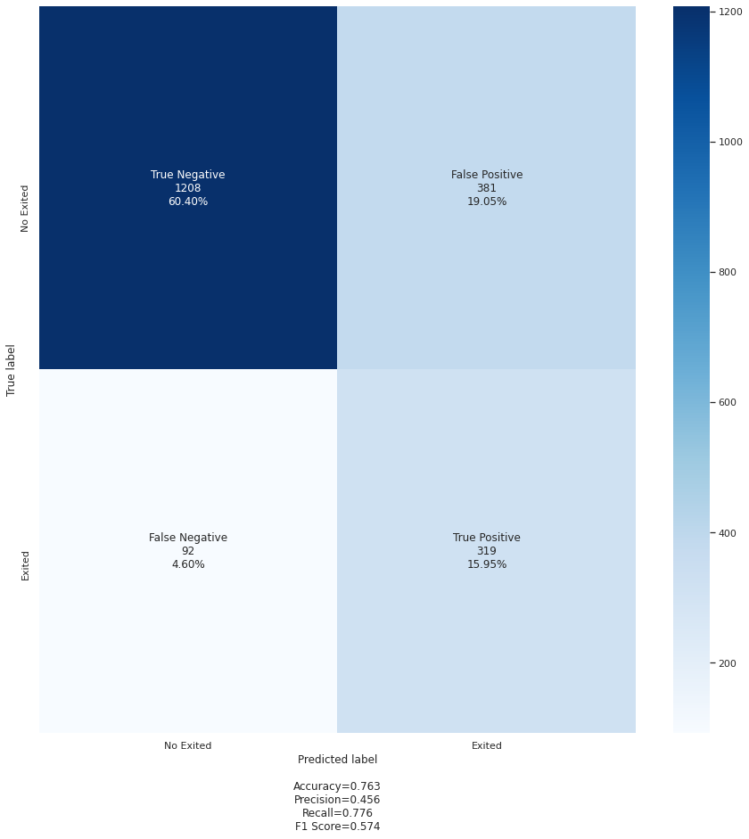

```python
# Confusion Matrix on unsee tet set
import seaborn as sns
from sklearn.metrics import accuracy_score, confusion_matrix, precision_score, recall_score, f1_score, precision_recall_curve, auc
y_pred1= model.predict(X_test)
for i in range(len(y_test)):
  if y_pred1[i]> 0.15: ## the optimal threshold we found above
    y_pred1[i] = 1
  else:
    y_pred1[i] =0

cm2 = confusion_matrix(y_test,y_pred1)
labels = ['True Negative','False Positive','False Negative','True Positive']
categories = ['No Exited', 'Exited']
make_confusion_matrix(cm2,group_names=labels, categories=categories, cmap='Blues')
```

**Observation:**

- After changing the threshold to 0.15 in the confusion matric calculation, we can see the Recall score reached to 0.776
- There 411 customers Exited in the test dataset and yet 92 Exited customers are not identified (false negative) which remains issues. Our objective must be determine as many Exited customers as possible since those can have a big negative impact for the Bank.
- Let's try to find ways to reduce the number of false negative with different models.

## Model-2

#### Let's try another architecture to get the better Recall

There are some basic Hyperparameters which can help to get the better model performance.

#### Model with EarlyStopping

```python
# Training Multi-layer perceptron with 2 hidden layers

# adding earlystopping callback
es = keras.callbacks.EarlyStopping(monitor='val_loss',
                                   min_delta = 0,
                                   patience = 15,
                                   verbose =0, mode='min', restore_best_weights=True
                                   )
Model2 = Sequential()

# Initializing the weights using hue_normal
Model2.add(Dense(65, input_shape=(11, ), kernel_initializer='he_normal', activation='relu'))
Model2.add(Dropout(0.5))
Model2.add(Dense(65, kernel_initializer='he_normal', activation='relu'))
Model2.add(Dropout(0.5))
Model2.add(Dense(1, kernel_initializer='he_normal', activation='sigmoid'))

Model2.compile(Adam(lr=0.001), loss='binary_crossentropy', metrics=['Recall'])

his_mod2 = Model2.fit(X_train, y_train, validation_split=0.2, batch_size=15, epochs=40, callbacks=[es], shuffle=True, verbose=1)
```

Plotting the train and validation loss

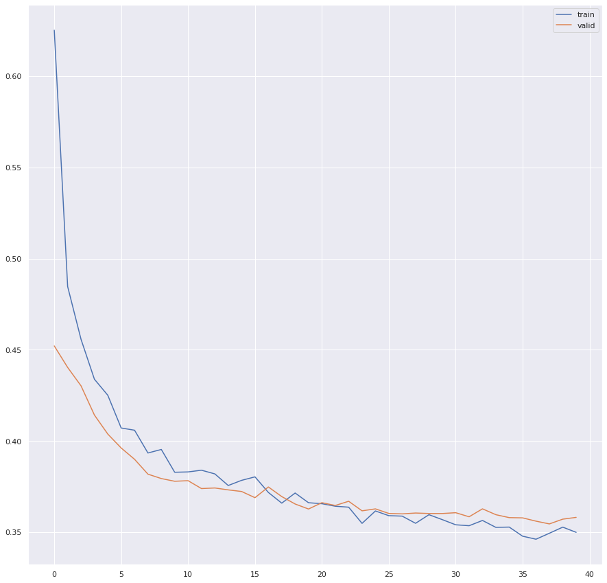

```python
# Capturing learning history per epoch
hist = pd.DataFrame(his_mod2.history)
hist['epoch'] = his_mod2.epoch

# Plotting Recall at different epochs
plt.plot(hist['loss'])
plt.plot(hist['val_loss'])
plt.legend(("train","valid"), loc=0)
```

Plotting confusion matrix

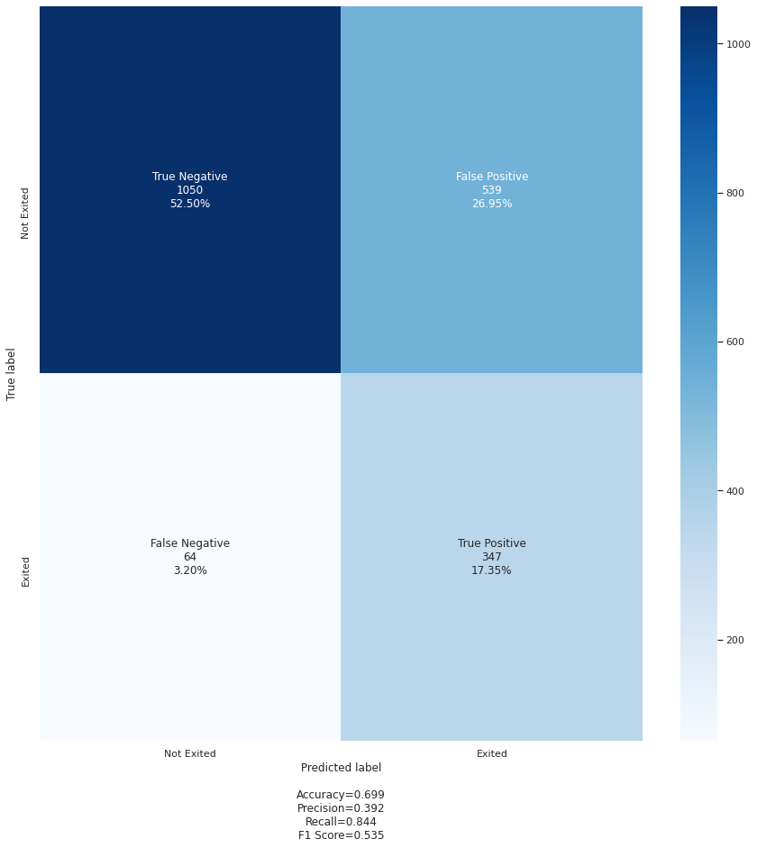

```python
# Confusion Matrix on unsee test set
y_pred1 = Model2.predict(X_test)
for i in range(len(y_test)):
  if y_pred1[i] > 0.15: # optimal threshold found above
    y_pred1[i] = 1
  else:
    y_pred1[i] = 0

cm2 = confusion_matrix(y_test, y_pred1)
labels = ['True Negative', 'False Positive', 'False Negative', 'True Positive']
categories = ['Not Exited','Exited']
make_confusion_matrix(cm2, group_names=labels,categories=categories, cmap='Blues')
```

**Observation:**

- Recall increase to 84% which is better than the previous ANN model: 77%
- Let's try weighted loss for imbalance dataset.

### Weighted loss to account for large class imbalance in train dataset

- we will adjust the class imbalance by giving additional weight to the loss associated to errors made on Exited Customers detection.

We will use our second ANN model and apply weighted loss

```python
from sklearn.utils import class_weight
class_weights = class_weight.compute_class_weight('balanced',np.unique(y_train), np.array([y_train.iloc[i] for i in range(len(y_train))]))
# 'balanced' corresponds to : n_samples / (n_classes * np.bincount(y))
class_weights = dict(enumerate(class_weights))
class_weights
```

```
{0: 0.627549419516787, 1: 2.4600246002460024}
```

- The class 'Exited'(y=1) is assigned a weight of 2.46 vs 0.62 for the class 'Not Exited' due to the very low as we detected during data exploration. This allows the model to give more importance to the errors made on Exited cases during training.

Training the model

```python
Model2.fit(X_train, y_train, batch_size=15, epochs=40, class_weight=class_weights, shuffle=True)
```

```
<keras.callbacks.History at 0x7efc84e66ad0>
```

```python
score_weighted = Model2.evaluate(X_test, y_test)
```

Plotting confusion matrix

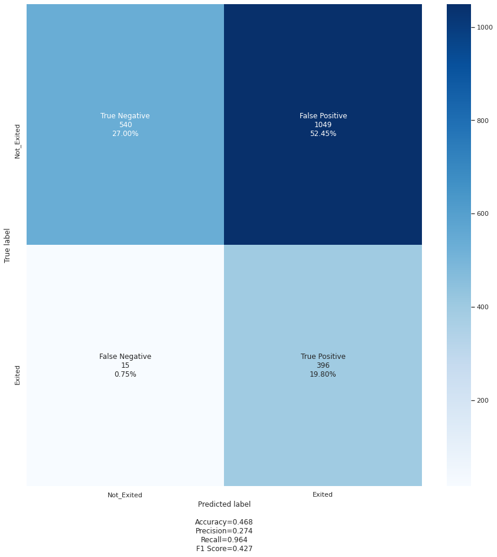

```python
# Confusion Matrix on unsee test set
y_pred1 = Model2.predict(X_test)
for i in range(len(y_test)):
  if y_pred1[i] > 0.15:
    y_pred1[i] = 1
  else:
    y_pred1[i] = 0

cm2 = confusion_matrix(y_test, y_pred1)
labels = ['True Negative','False Positive','False Negative','True Positive']
categories = [ 'Not_Exited','Exited']
make_confusion_matrix(cm2,
                      group_names=labels,
                      categories=categories,
                      cmap='Blues')
```

### Conclusion and key takeaways

- Final conclusion about the analysis
- As we can see here the Recall is increased to 96% which is better.
- Precision and Accuracy are low, however we still should choose this final model. As the Bank, customer exited or leave is very important (lossing benefit). So, we rather say customer will leave, then customer not leave than we say customer not leave, but customer are leaving.
- We can also try to implement Resampling techniques to balanced the dataset and train the model.
- Customer live in Germany have rate exited from the Bank than other Geography (France, and Spain). The Bank might need to come up with some stategies to improve customer statification in Germany. Also Female customer more likely exited or leave the Bank than Men customer. For that, Marketing team of the Bank can come up with some promotions to encorage women customer to Bank service more and stay with the Bank.